# Pumpkin Seed Classification using LDA, QDA, and SVM

Stephen Situ

2022-12-11

This is a project on using three similar machine learning techniques for classification of labeled data with continuous features. Linear Discriminant Analysis (LDA) tries to find a linear combination of features to classify data, this boundary takes on a shape of a line or hyperplane. This assumes that the data is normal and the covariance matrices are identical. Quadratic Discriminant Analysis (QDA) is similar to LDA, but the boundary is non-linear. Support Vector Machines (SVM) has support vectors that create the boundary and then the algorithm tries to maximize the distance between the different groups, known as maximizing the margin of separation. SVM does not require any assumptions and is more flexible.

First we conducted a Shapiro-wilk test to test the normality of the data set and found that we could not assume the data is normally distributed. Then we proceeded to use all 3 methods and evaluated their accuracy. They all gave a similar accuracy of 88% for the training data. To investigate further, we created a scatter plot of correct and incorrect predictions. This lets us see the results of each method in depth.

Original Data set: https://www.kaggle.com/datasets/muratkokludataset/pumpkin-seeds-dataset

# Install Packages

```r
install.packages("tidyverse", repos = "http://cran.us.r-project.org")
install.packages("e1071", repos = "http://cran.us.r-project.org")
install.packages("MASS", repos = "http://cran.us.r-project.org")
install.packages("caret", repos = "http://cran.us.r-project.org")
install.packages("readxl", repos = "http://cran.us.r-project.org")
library(tidyverse)
library(e1071)
library(MASS)
library(caret)
library(readxl)
```

# Read Data from xlsx

```r
df <- read_xlsx("Pumpkin_Seeds_Dataset.xlsx", sheet=1)
```

# Summary

```r
summary(df)
```

```
##       Area          Perimeter      Major_Axis_Length Minor_Axis_Length
##  Min.   : 47939   Min.   : 868.5   Min.   :320.8     Min.   :152.2
##  1st Qu.: 70765   1st Qu.:1048.8   1st Qu.:415.0     1st Qu.:211.2
##  Median : 79076   Median :1123.7   Median :449.5     Median :224.7
##  Mean   : 80658   Mean   :1130.3   Mean   :456.6     Mean   :225.8
##  3rd Qu.: 89758   3rd Qu.:1203.3   3rd Qu.:492.7     3rd Qu.:240.7
##  Max.   :136574   Max.   :1559.5   Max.   :661.9     Max.   :305.8
##   Convex_Area     Equiv_Diameter   Eccentricity       Solidity
##  Min.   : 48366   Min.   :247.1   Min.   :0.4921   Min.   :0.9186
##  1st Qu.: 71512   1st Qu.:300.2   1st Qu.:0.8317   1st Qu.:0.9883
##  Median : 79872   Median :317.3   Median :0.8637   Median :0.9903
##  Mean   : 81508   Mean   :319.3   Mean   :0.8609   Mean   :0.9895
##  3rd Qu.: 90798   3rd Qu.:338.1   3rd Qu.:0.8970   3rd Qu.:0.9915
##  Max.   :138384   Max.   :417.0   Max.   :0.9481   Max.   :0.9944
##      Extent         Roundness      Aspect_Ration    Compactness
##  Min.   :0.4680   Min.   :0.5546   Min.   :1.149   Min.   :0.5608
##  1st Qu.:0.6589   1st Qu.:0.7519   1st Qu.:1.801   1st Qu.:0.6635
##  Median :0.7130   Median :0.7977   Median :1.984   Median :0.7077
##  Mean   :0.6932   Mean   :0.7915   Mean   :2.042   Mean   :0.7041
##  3rd Qu.:0.7402   3rd Qu.:0.8343   3rd Qu.:2.262   3rd Qu.:0.7435
##  Max.   :0.8296   Max.   :0.9396   Max.   :3.144   Max.   :0.9049
##     Class
##  Length:2500
##  Class :character
##  Mode  :character
##
##
##
```

```r
str(df)
```

```
## tibble [2,500 × 13] (S3: tbl_df/tbl/data.frame)
##  $ Area             : num [1:2500] 56276 76631 71623 66458 66107 ...
##  $ Perimeter        : num [1:2500] 888 1068 1083 992 998 ...
##  $ Major_Axis_Length: num [1:2500] 326 417 436 382 384 ...
##  $ Minor_Axis_Length: num [1:2500] 220 234 211 223 220 ...
##  $ Convex_Area      : num [1:2500] 56831 77280 72663 67118 67117 ...
##  $ Equiv_Diameter   : num [1:2500] 268 312 302 291 290 ...
##  $ Eccentricity     : num [1:2500] 0.738 0.828 0.875 0.812 0.819 ...
##  $ Solidity         : num [1:2500] 0.99 0.992 0.986 0.99 0.985 ...
##  $ Extent           : num [1:2500] 0.745 0.715 0.74 0.74 0.675 ...
##  $ Roundness        : num [1:2500] 0.896 0.844 0.767 0.849 0.834 ...
##  $ Aspect_Ration    : num [1:2500] 1.48 1.78 2.07 1.71 1.74 ...
##  $ Compactness      : num [1:2500] 0.821 0.749 0.693 0.762 0.756 ...
##  $ Class            : chr [1:2500] "Çerçevelik" "Çerçevelik" "Çerçevelik" "Çerçevelik" ...
```

# Head

```r
head(df)
```

```
## # A tibble: 6 × 13
##    Area Perimeter Major…¹ Minor…² Conve…³ Equiv…⁴ Eccen…⁵ Solid…⁶ Extent Round…⁷
##   <dbl>     <dbl>   <dbl>   <dbl>   <dbl>   <dbl>   <dbl>   <dbl>  <dbl>   <dbl>
## 1 56276      888.    326.    220.   56831    268.   0.738   0.990  0.745   0.896
## 2 76631     1068.    417.    234.   77280    312.   0.828   0.992  0.715   0.844
## 3 71623     1083.    436.    211.   72663    302.   0.875   0.986  0.74    0.767
## 4 66458      992.    382.    223.   67118    291.   0.812   0.990  0.740   0.849
## 5 66107      998.    384.    220.   67117    290.   0.819   0.985  0.675   0.834
## 6 73191     1041.    406.    231.   73969    305.   0.822   0.990  0.716   0.848
## # … with 3 more variables: Aspect_Ration <dbl>, Compactness <dbl>, Class <chr>,
## #   and abbreviated variable names ¹Major_Axis_Length, ²Minor_Axis_Length,
## #   ³Convex_Area, ⁴Equiv_Diameter, ⁵Eccentricity, ⁶Solidity, ⁷Roundness
```

# Rename Aspect_Ration to Aspect_ratio

```r
pumpkin_data <- df %>% rename(Aspect_ratio = Aspect_Ration)
```

# Change Class to a factor variable

```r
pumpkin_data$Class = as.factor(pumpkin_data$Class)
str(pumpkin_data)
```

```
## tibble [2,500 × 13] (S3: tbl_df/tbl/data.frame)
##  $ Area             : num [1:2500] 56276 76631 71623 66458 66107 ...
##  $ Perimeter        : num [1:2500] 888 1068 1083 992 998 ...
##  $ Major_Axis_Length: num [1:2500] 326 417 436 382 384 ...
##  $ Minor_Axis_Length: num [1:2500] 220 234 211 223 220 ...
##  $ Convex_Area      : num [1:2500] 56831 77280 72663 67118 67117 ...
##  $ Equiv_Diameter   : num [1:2500] 268 312 302 291 290 ...
##  $ Eccentricity     : num [1:2500] 0.738 0.828 0.875 0.812 0.819 ...
##  $ Solidity         : num [1:2500] 0.99 0.992 0.986 0.99 0.985 ...
##  $ Extent           : num [1:2500] 0.745 0.715 0.74 0.74 0.675 ...
##  $ Roundness        : num [1:2500] 0.896 0.844 0.767 0.849 0.834 ...
##  $ Aspect_ratio     : num [1:2500] 1.48 1.78 2.07 1.71 1.74 ...
##  $ Compactness      : num [1:2500] 0.821 0.749 0.693 0.762 0.756 ...
##  $ Class            : Factor w/ 2 levels "Çerçevelik","Ürgüp Sivrisi": 1 1 1 1 1 1 1 1 1 1 ...
```

# Set seed for random numbers

```r
set.seed(123)
```

# Use Shapiro-wilk test to test for Normality

# We check if p value >= 0.05 to check for normality

# All p-values did not pass the test, so we cannot assume they are normally distributed

```r
shapiro.test(pumpkin_data$Area)
```

```
##
##  Shapiro-Wilk normality test
##
## data:  pumpkin_data$Area
## W = 0.9834, p-value < 2.2e-16
```

```r
shapiro.test(pumpkin_data$Perimeter)
```

```
##
##  Shapiro-Wilk normality test
##
## data:  pumpkin_data$Perimeter
## W = 0.98795, p-value = 1.076e-13
```

```r
shapiro.test(pumpkin_data$Major_Axis_Length)
```

```
##
##  Shapiro-Wilk normality test
##
## data:  pumpkin_data$Major_Axis_Length
## W = 0.98202, p-value < 2.2e-16
```

```r
shapiro.test(pumpkin_data$Minor_Axis_Length)
```

```
##
##  Shapiro-Wilk normality test
##
## data:  pumpkin_data$Minor_Axis_Length
## W = 0.99816, p-value = 0.00591
```

```r
shapiro.test(pumpkin_data$Convex_Area)
```

```
##
##  Shapiro-Wilk normality test
##
## data:  pumpkin_data$Convex_Area
## W = 0.98344, p-value < 2.2e-16
```

```r
shapiro.test(pumpkin_data$Equiv_Diameter)
```

```
##
##  Shapiro-Wilk normality test
##
## data:  pumpkin_data$Equiv_Diameter
## W = 0.9935, p-value = 4.331e-09
```

```r
shapiro.test(pumpkin_data$Eccentricity)
```

```
##
##  Shapiro-Wilk normality test
##
## data:  pumpkin_data$Eccentricity
## W = 0.96585, p-value < 2.2e-16
```

```r
shapiro.test(pumpkin_data$Solidity)
```

```
##
##  Shapiro-Wilk normality test
##
## data:  pumpkin_data$Solidity
## W = 0.70041, p-value < 2.2e-16
```

```r
shapiro.test(pumpkin_data$Extent)
```

```
##
##  Shapiro-Wilk normality test
##
## data:  pumpkin_data$Extent
## W = 0.90792, p-value < 2.2e-16
```

```r
shapiro.test(pumpkin_data$Roundness)
```

```
##
##  Shapiro-Wilk normality test
##
## data:  pumpkin_data$Roundness
## W = 0.98731, p-value = 3.924e-14
```

```r
shapiro.test(pumpkin_data$Aspect_ratio)
```

```
##
##  Shapiro-Wilk normality test
##
## data:  pumpkin_data$Aspect_ratio
## W = 0.97237, p-value < 2.2e-16
```

```r
shapiro.test(pumpkin_data$Compactness)
```

```
##
##  Shapiro-Wilk normality test
##
## data:  pumpkin_data$Compactness
## W = 0.99305, p-value = 1.512e-09
```

# It is difficult to visualize the data in a meaningful way due to having 12 features

# We will use Area and Aspect Ratio as our labels

# It is possible to see a boundary that seperates the two seed categories

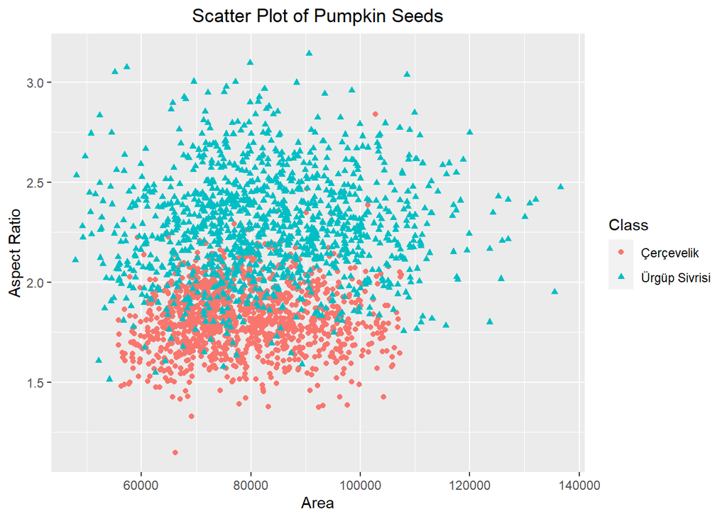

```r
ggplot(data=pumpkin_data) + geom_point(mapping=aes(x=Area,y=Aspect_ratio,shape=Class,colour=Class)) +
  labs(y = "Aspect Ratio",x="Area") +
  ggtitle("Scatter Plot of Pumpkin Seeds") + theme(plot.title = element_text(hjust = 0.5))
```

# First we try LDA and obtain 88.08% accuracy

```r
lda_model <- lda(Class~., data=pumpkin_data, type= 'C-Classification', cost=10)
pred_lda <- predict(lda_model, pumpkin_data)
cmatrix_lda <- table(predicted_values = pred_lda$class, true_values= pumpkin_data$Class)
confusionMatrix(cmatrix_lda)
```

```
## Confusion Matrix and Statistics
##
##                 true_values
## predicted_values Çerçevelik Ürgüp Sivrisi
##    Çerçevelik          1185           183
##    Ürgüp Sivrisi        115          1017
##
##                Accuracy : 0.8808
##                  95% CI : (0.8675, 0.8932)
##     No Information Rate : 0.52
##     P-Value [Acc > NIR] : < 2.2e-16
##
##                   Kappa : 0.7607
##
##  Mcnemar's Test P-Value : 0.0001039
##
##             Sensitivity : 0.9115
##             Specificity : 0.8475
##          Pos Pred Value : 0.8662
##          Neg Pred Value : 0.8984
##              Prevalence : 0.5200
##          Detection Rate : 0.4740
##    Detection Prevalence : 0.5472
##       Balanced Accuracy : 0.8795
##
##        'Positive' Class : Çerçevelik
##
```

# Now we try QDA, we get 88.32% accuracy

```r
qda_model <- qda(Class~., data=pumpkin_data, type= 'C-Classification', cost=10)
pred_qda <- predict(qda_model, pumpkin_data)
cmatrix_qda <- table(predicted_values = pred_qda$class, true_values= pumpkin_data$Class)
confusionMatrix(cmatrix_qda)
```

```
## Confusion Matrix and Statistics
##
##                 true_values
## predicted_values Çerçevelik Ürgüp Sivrisi
##    Çerçevelik          1192           184
##    Ürgüp Sivrisi        108          1016
##
##                Accuracy : 0.8832
##                  95% CI : (0.87, 0.8955)
##     No Information Rate : 0.52
##     P-Value [Acc > NIR] : < 2.2e-16
##
##                   Kappa : 0.7655
##
##  Mcnemar's Test P-Value : 1.139e-05
##
##             Sensitivity : 0.9169
##             Specificity : 0.8467
##          Pos Pred Value : 0.8663
##          Neg Pred Value : 0.9039
##              Prevalence : 0.5200
##          Detection Rate : 0.4768
##    Detection Prevalence : 0.5504
##       Balanced Accuracy : 0.8818
##
##        'Positive' Class : Çerçevelik
##
```